# Projekt zaliczeniowy, temat 4

Sułkowska Jolanta, 415174

2025-01-04

# Przygotowanie danych

- Załaduj dane i przekształć zmienne jakościowe na typ `factor`.
- Wyświetl podsumowanie danych. Na podstawie tego określ, które zmienne są jakościowe, a które ilościowe.

```r
library(readxl)
setwd("C:/Users/jolas/Desktop/STUDIA/6. wybrane pakiety do analizy danych")
dane=read_excel("temat4.xlsx")
head(dane)
```

```
## # A tibble: 6 × 6
##   Numer_indeksu Płeć      Kierunek_studiów  Wiek Czas_nauki Średnia_ocen
##           <dbl> <chr>     <chr>            <dbl>      <dbl>        <dbl>
## 1        400001 Mężczyzna Ekonomia            27       3.45         2.88
## 2        400002 Mężczyzna Psychologia         23       2.5          3.47
## 3        400003 Kobieta   Psychologia         21       4.38         3
## 4        400004 Kobieta   Ekonomia            25       2.6          3.03
## 5        400005 Mężczyzna Biologia            22       4.77         3.65
## 6        400006 Mężczyzna Ekonomia            24       2.81         3.36
```

```r
# rozpoznaję zmienne jakościowe: płeć i kierunek studiów
dane$Płeć= as.factor(dane$Płeć)
dane$Kierunek_studiów= as.factor(dane$Kierunek_studiów)
summary(dane)
```

```
##  Numer_indeksu           Płeć        Kierunek_studiów      Wiek
##  Min.   :400001   Kobieta  :293   Biologia   :109     Min.   :16.00
##  1st Qu.:400124   Mężczyzna:196   Ekonomia   :119     1st Qu.:22.00
##  Median :400250   NA's     : 11   Informatyka:127     Median :23.00
##  Mean   :400250                   Psychologia:140     Mean   :23.09
##  3rd Qu.:400375                   NA's       :  5     3rd Qu.:24.00
##  Max.   :400500                                       Max.   :29.00
##  NA's   :15                                           NA's   :11
##    Czas_nauki      Średnia_ocen
##  Min.   : 0.270   Min.   :2.17
##  1st Qu.: 2.950   1st Qu.:2.91
##  Median : 3.880   Median :3.14
##  Mean   : 4.259   Mean   :3.14
##  3rd Qu.: 5.130   3rd Qu.:3.35
##  Max.   :12.460   Max.   :4.10
##  NA's   :8        NA's   :9
```

# Obsługa brakujących danych

Sprawdź, czy w zestawie danych występują wartości `NA`. Jeśli tak:

- Dla zmiennych jakościowych zastąp brakujące wartości najczęściej występującą kategorią.
- Dla zmiennych ilościowych zastąp brakujące wartości średnią. Pamiętaj, aby dla zmiennej “wiek” średnia była zaokrąglona do pełnych wartości.
- Jeżeli `NA` pojawia się w kolumnie Numer_indeksu, usuń tę obserwację ze zbioru danych

```r
sum(is.na(dane$Numer_indeksu))
```

```
## [1] 15
```

```r
sum(is.na(dane$Płeć))
```

```
## [1] 11
```

```r
sum(is.na(dane$Kierunek_studiów))
```

```
## [1] 5
```

```r
sum(is.na(dane$Wiek))
```

```
## [1] 11
```

```r
sum(is.na(dane$Czas_nauki))
```

```
## [1] 8
```

```r
sum(is.na(dane$Średnia_ocen))
```

```
## [1] 9
```

```r
dane <- dane[!is.na(dane$Numer_indeksu), ]
sredni_wiek <- round(mean(dane$Wiek, na.rm = TRUE))
dane$Wiek[is.na(dane$Wiek)] <- sredni_wiek
library(Hmisc)
dane$Czas_nauki <- impute(dane$Czas_nauki, mean)
dane$Średnia_ocen <- impute(dane$Średnia_ocen, mean)
summary(dane)
```

```
##
##  8 values imputed to 4.277589
##
##
##  9 values imputed to 3.139391
```

```
##  Numer_indeksu           Płeć        Kierunek_studiów      Wiek
##  Min.   :400001   Kobieta  :285   Biologia   :106     Min.   :18.0
##  1st Qu.:400124   Mężczyzna:189   Ekonomia   :117     1st Qu.:22.0
##  Median :400250   NA's     : 11   Informatyka:124     Median :23.0
##  Mean   :400250                   Psychologia:133     Mean   :23.1
##  3rd Qu.:400375                   NA's       :  5     3rd Qu.:24.0
##  Max.   :400500                                       Max.   :29.0
##    Czas_nauki      Średnia_ocen
##  Min.   : 0.270   Min.   :2.170
##  1st Qu.: 2.970   1st Qu.:2.910
##  Median : 3.920   Median :3.139
##  Mean   : 4.278   Mean   :3.139
##  3rd Qu.: 5.120   3rd Qu.:3.350
##  Max.   :12.460   Max.   :4.100
```

```r
head(dane)
```

```
## # A tibble: 6 × 6
##   Numer_indeksu Płeć      Kierunek_studiów  Wiek Czas_nauki Średnia_ocen
##           <dbl> <fct>     <fct>            <dbl>      <dbl>        <dbl>
## 1        400001 Mężczyzna Ekonomia            27       3.45         2.88
## 2        400002 Mężczyzna Psychologia         23       2.5          3.47
## 3        400003 Kobieta   Psychologia         21       4.38         3
## 4        400004 Kobieta   Ekonomia            25       2.6          3.03
## 5        400005 Mężczyzna Biologia            22       4.77         3.65
## 6        400006 Mężczyzna Ekonomia            24       2.81         3.36
```

```r
sum(is.na(dane))
```

```
## [1] 16
```

```r
# teraz zmienne jakościowe zastępuję modą
najczestsza_plec <- names(which.max(table(dane$Płeć)))
najczestszy_kierunek <- names(which.max(table(dane$Kierunek_studiów)))
dane$Płeć[is.na(dane$Płeć)] <- najczestsza_plec
dane$Kierunek_studiów[is.na(dane$Kierunek_studiów)] <- najczestszy_kierunek
sum(is.na(dane))
```

```
## [1] 0
```

# Funkcja wyznaczająca kwotę stypendium

Napisz funkcję, która na podstawie średniej określi, czy danej osobie należy się stypendium, a jeśli tak, to jakiej wysokości.

Progi otrzymania stypendium:

- jeżeli średnia ≥ 4.5, to stypendium wynosi 750 zł,
- jeżeli średnia ≥ 4.7, to stypendium wynosi 850 zł,
- jeżeli średnia ≥ 4.9, to stypendium wynosi 950 zł.

Argumentem funkcji powinna być ramka danych.

Funkcja powinna zwrócić listę złożoną z 4 elementów:

- liczby przyznanych stypendiów,
- macierzy/ramki danych z numerami indeksów stypendystów wraz z wyliczonymi kwotami,
- miesięcznego kosztu stypendium (sumy wszystkich przyznanych stypendiów).

```r
ramka_danych = dane[, c("Numer_indeksu", "Średnia_ocen")]
summary(ramka_danych)
```

```
##
##  9 values imputed to 3.139391
```

```
##  Numer_indeksu     Średnia_ocen
##  Min.   :400001   Min.   :2.170
##  1st Qu.:400124   1st Qu.:2.910
##  Median :400250   Median :3.139
##  Mean   :400250   Mean   :3.139
##  3rd Qu.:400375   3rd Qu.:3.350
##  Max.   :400500   Max.   :4.100
```

```r
oblicz_stypendium = function(ramka_danych) {
  # tworzenie pustego wektora na kwoty stypendiów
  stypendia <- numeric(nrow(ramka_danych)) #wektor wypełniony zerami dla każdego studenta

  # kwoty stypendium
  stypendia[ramka_danych$Średnia_ocen >= 4.9] <- 950
  stypendia[ramka_danych$Średnia_ocen >= 4.7 & ramka_danych$Średnia_ocen < 4.9] <- 850
  stypendia[ramka_danych$Średnia_ocen >= 4.5 & ramka_danych$Średnia_ocen < 4.7] <- 750

  stypendysci <- ramka_danych[stypendia > 0, ]  # Wybieramy tylko osoby, które otrzymały stypendium
  stypendysci$Kwota <- stypendia[stypendia > 0]  # Dodajemy kolumnę "Kwota" z odpowiednimi kwotami
  stypendysci$Średnia_ocen <- NULL  # Usuwamy kolumnę "Średnia_ocen" (nie ma w poleceniu zadania)
  # Liczba przyznanych stypendiów
  liczba_stypendiow <- nrow(stypendysci)

  # Całkowity koszt stypendiów
  koszt_stypendiow <- sum(stypendysci$Kwota)

  # Zwrócenie listy wyników
  wynik <- list(
    liczba_stypendiow = liczba_stypendiow,
    stypendysci = stypendysci,
    koszt_stypendiow = koszt_stypendiow
  )

  return(wynik)
}

wynik <- oblicz_stypendium(ramka_danych)
print(wynik)
```

```
## $liczba_stypendiow
## [1] 0
##
## $stypendysci
## # A tibble: 0 × 2
## # ℹ 2 variables: Numer_indeksu <dbl>, Kwota <dbl>
##
## $koszt_stypendiow
## [1] 0
```

```r
# Nikt ze studentów nie miał średniej powyżej 4,50 i dlatego nikt nie otrzymał stypendium,
# a całkowity koszt stypendiów to 0

summary(ramka_danych$Średnia_ocen) #rzeczywiście - najwyzsza srednia: 4,1
```

```
##
##  9 values imputed to 3.139391
```

```
##    Min. 1st Qu.  Median    Mean 3rd Qu.    Max.
##   2.170   2.910   3.139   3.139   3.350   4.100
```

```r
# dodajmy jednak sztucznego studenta, któremu należy się stypendium
# ramka_danych <- rbind(ramka_danych, data.frame(Numer_indeksu = 99999, Średnia_ocen = 4.8))
# summary(ramka_danych$Średnia_ocen) # teraz najwyzsza srednia: 4,8

# wynik <- oblicz_stypendium(ramka_danych)
# print(wynik) #i teraz juz jest wypłacone jedno stypendium
```

# Wykres słupkowy dla kierunku studiów i płci

- Używając biblioteki ggplot, stwórz wykres słupkowy (pionowe słupki) porównujący kierunek studiów z płcią. Wykres powinien mieć odpowiednio podpisane osie, tytuł, legendę oraz zmienione kolory słupków i tła.

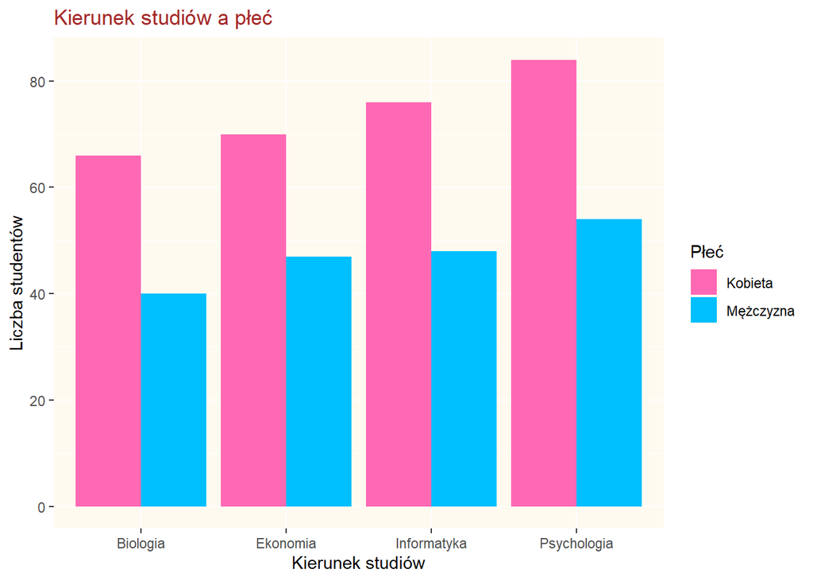

```r
library(ggplot2)
ggplot(dane, aes(x = Kierunek_studiów, fill = Płeć)) +
  geom_bar(position = "dodge") +
  labs(
    title = "Kierunek studiów a płeć",
    x = "Kierunek studiów",
    y = "Liczba studentów"
  )+scale_fill_manual(values = c("hotpink","deepskyblue"))+theme(
    plot.title = element_text(color="brown"),
    panel.background = element_rect(fill = 'floralwhite')
        )
```

- Na podstawie otrzymanego wykresu, opisz, jakie wnioski można wyciągnąć na temat zależności między płcią a kierunkiem studiów w zbiorze danych.

Na wszystkich kierunkach studiów jest więcej kobiet niż mężczyzn. Mężczyźni zazwyczaj stanowią około 2/5 całego kierunku. Nie ma znaczenia jaki to kierunek.

# Histogram dla średniej ocen

- Stwórz histogram dla średniej ocen, dodając linię reprezentującą jądrowy estymator gęstości oraz przerywane linie oznaczające średnią, modę i medianę. Oznacz osie, nadaj tytuł, zmień kolory histogramu oraz linii i dodaj legendę (legendy powinny uwzględniać styl linii, np. przerywana linia w legendzie odpowiada przerywanej linii na wykresie).

```r
library(RVAideMemoire) #potrzebuję do mody
```

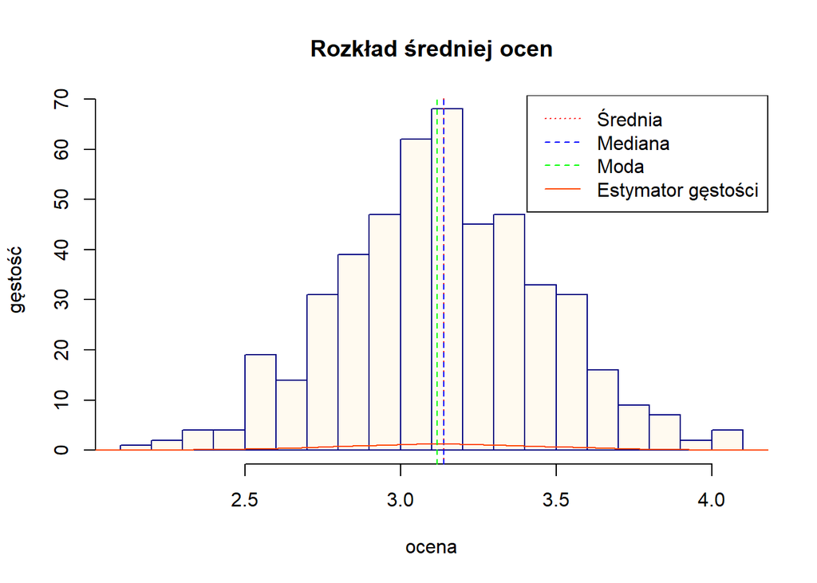

```r
hist(dane$Średnia_ocen, breaks = 15, main="Rozkład średniej ocen", ylab="gęstość", xlab="ocena",
     col = "floralwhite",  border = "navy")
abline(v=mean(dane$Średnia_ocen), col="red",lty = 3)
abline(v=median(dane$Średnia_ocen),col="blue",lty = 2)
lines(density(dane$Średnia_ocen), col="orangered",lty = 1)
abline(v =mod(dane$Średnia_ocen), col = "green", lty = 2)

legend(
  "topright",
  legend = c("Średnia", "Mediana", "Moda", "Estymator gęstości"),
  col = c("red", "blue", "green", "orangered"),
  lty = c(3, 2, 2, 1),  # styl linii (przerywana dla statystyk; ciągła dla gęstości)
  bg = "white"
)
```

```r
#akurat średnia pokrywa się z medianą
```

- Określ charakterystykę rozkładu: modalność, skośność i symetryczność.

Jest to rozkład jednomodalny, przypomina rozkład Gaussa; jest symetryczny - moda, mediana i średnia znajdują się w tym samym miejscu.

# Wykresy pudełkowe dla czasu nauki a kierunek studiów

- Przy użyciu ggplot, narysuj wykresy pudełkowe dla czasu nauki w podziale na kierunek studiów. Wykres powinien mieć podpisane osie, tytuł oraz zmienione kolory.

```
## Defaulting to continuous.
```

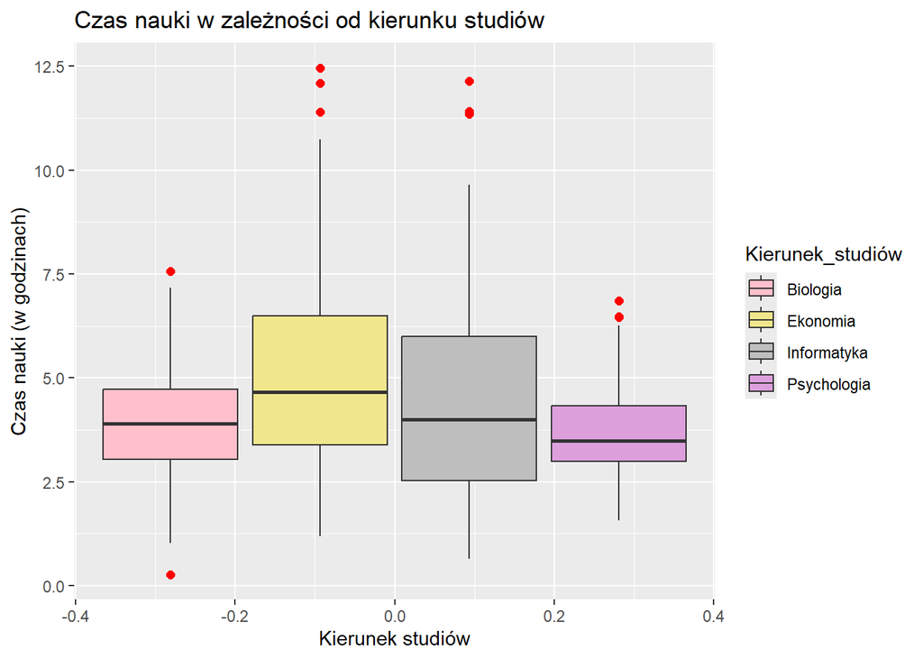

```r
ggplot(dane, aes(y = Czas_nauki, fill = Kierunek_studiów)) +
  geom_boxplot(outlier.color = "red", outlier.shape = 16, outlier.size = 2) +
  labs(
    title = "Czas nauki w zależności od kierunku studiów",
    x = "Kierunek studiów",
    y = "Czas nauki (w godzinach)"
  ) + scale_fill_manual(values = c("pink", "khaki", "gray", "plum"))
```

- Na podstawie wykresu określ, czy rozkłady czasu nauki różnią się w zależności od kierunku. Który kierunek wymaga średnio najwięcej czasu, a który najmniej? Który kierunek charakteryzuje się największą wariancją? Czy są widoczne wartości odstające i jak je zidentyfikować?

Rozkłady czasu nauki są zróżnicowane. Informatyka i ekonomia wymagają więcej czasu, niż biologia czy psychologia. Studenci kierunku ekonomia poświęcają średnio najwięcej czasu na naukę, podczas gdy najmniej wymagający czasowo jest kierunek psychologia. Największy rozrzut ma informatyka - studenci informatyki uczą się średnio od 2,5 do nawet ponad 6 h. Widoczne są również wartości odstające (outliers) i zaznaczone są czerwonymi kropkami.

# Analiza rozkładu czasu nauki dla najliczniejszego kierunku studiów

- Wybierz czas nauki dla najliczniejszego kierunku studiów. Przeprowadź analizę rozkładu: przetestuj i porównaj co najmniej dwa różne rozkłady, wyestymuj ich parametry i oceń dopasowanie.

```r
summary(dane$Kierunek_studiów)
```

```
##    Biologia    Ekonomia Informatyka Psychologia
##         106         117         124         138
```

```r
#jak widać, najliczniejszy kierunek to Psychologia
#ale sprawdźmy to formalnie
table(dane$Kierunek_studiów)
```

```
##
##    Biologia    Ekonomia Informatyka Psychologia
##         106         117         124         138
```

```r
najliczniejszy = names(which.max(table(dane$Kierunek_studiów)))
najliczniejszy
```

```
## [1] "Psychologia"
```

```r
#jak widać, najliczniejszy kierunek to Psychologia
psychologia = najliczniejszy

dane_psychologia = subset(dane, Kierunek_studiów == psychologia)
czas_nauki = dane_psychologia$Czas_nauki

#install.packages("fitdistrplus")
#install.packages("ggplot2")
library(fitdistrplus)
library(ggplot2)

summary(czas_nauki)
```

```
##
##  1 values imputed to 4.277589
```

```
##    Min. 1st Qu.  Median    Mean 3rd Qu.    Max.
##   1.570   2.982   3.480   3.692   4.332   6.850
```

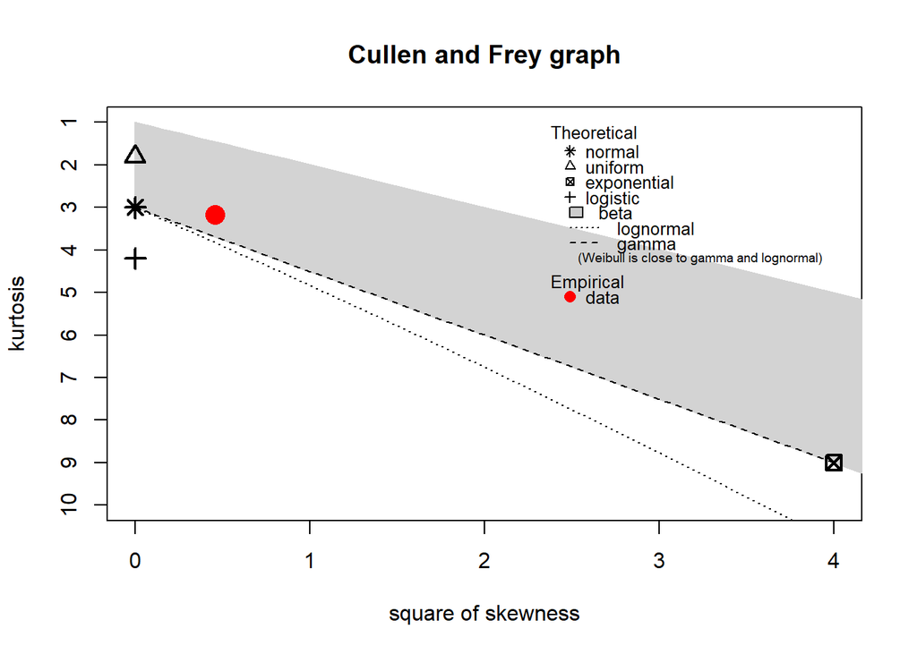

```
## summary statistics
## ------
## min:  1.57   max:  6.85
## median:  3.48
## mean:  3.691577
## estimated sd:  1.039111
## estimated skewness:  0.6761164
## estimated kurtosis:  3.176167
```

```r
value1 <- as.numeric(as.character(czas_nauki)) #dane w kolumnie czas_nauki będą traktowane jako liczby, bez tego nie działa
value1 <- value1[is.finite(value1)] # dane koniecznie muszą być skończone

# Funkcja descdist() z pakietu fitdistrplus: do dopasowania odpowiedniego rozkładu do danych.
# generuje wykres i wypisuje informacje, które pomagają w ocenie jak dobrze dane empiryczne pasują do wybranych rozkładów teoretycznych
descdist(value1, discrete = FALSE)
```

```r
normalize <- function(x) {
  return((x - min(x)) / (max(x) - min(x)))
}

normalized_value1 = normalize(value1)
normalized_value1[normalized_value1==0]=0.00001
normalized_value1[normalized_value1==1]=0.99999
range(normalized_value1) #wszystko w porządku
```

```
## [1] 0.00001 0.99999
```

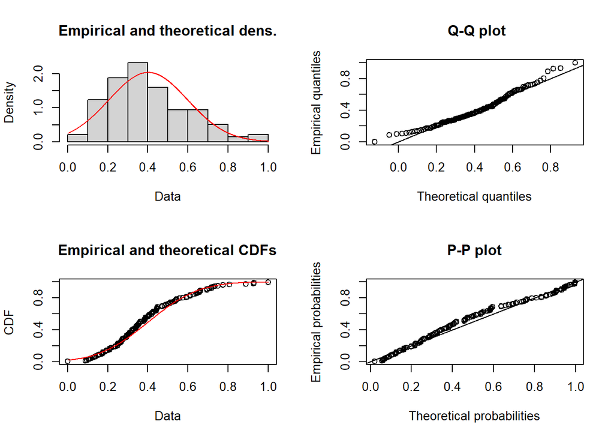

```r
fit_norm = fitdist(normalized_value1, "norm")
plot(fit_norm)
```

```r
fit_norm$estimate
```

```
##      mean        sd
## 0.4018138 0.1960866
```

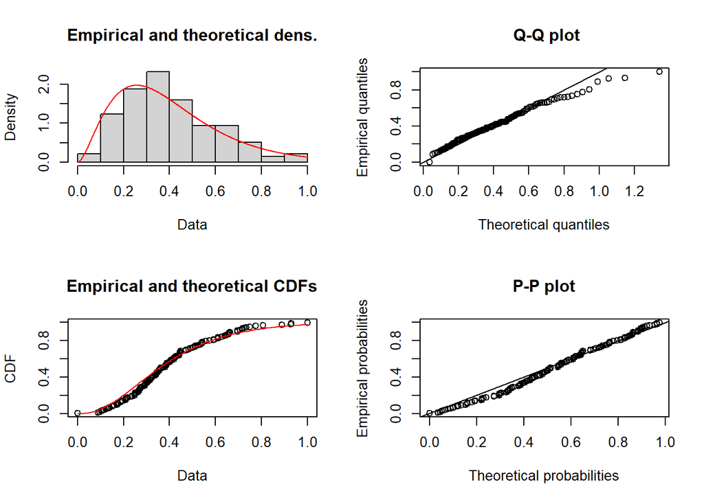

```r
fit_gamma = fitdist(normalized_value1, "gamma")
plot(fit_gamma)
```

```r
fit_gamma$estimate
```

```
##    shape     rate
## 2.765195 6.881851
```

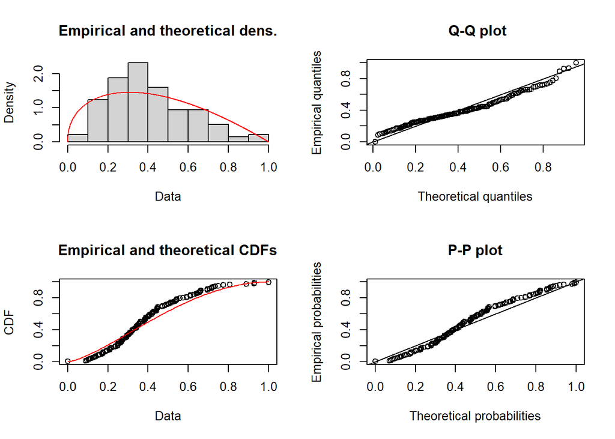

```r
fit_beta = fitdist(normalized_value1, "beta")
plot(fit_beta)
```

```r
fit_beta$estimate
```

```
##   shape1   shape2
## 1.447900 2.012435
```

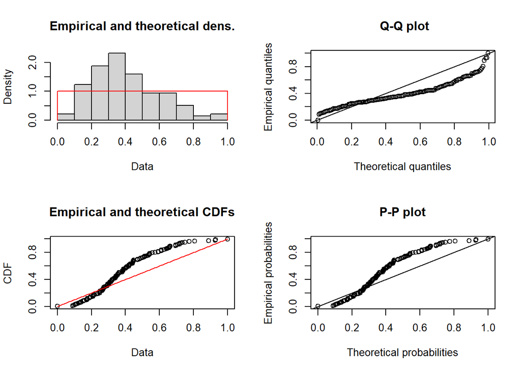

```r
fit_unif = fitdist(normalized_value1, "unif")
plot(fit_unif)
```

```r
fit_unif$estimate
```

```
##     min     max
## 0.00001 0.99999
```

```r
#Ocena dopasowania
gof_results = gofstat(list(fit_gamma,fit_beta, fit_unif,fit_norm), fitnames = c("Gamma", "Beta",  "Jedostajny", "Normalny"))
print(gof_results)
```

```
## Goodness-of-fit statistics
##                                  Gamma      Beta Jedostajny   Normalny
## Kolmogorov-Smirnov statistic 0.1012399 0.1220901  0.2481876 0.09359253
## Cramer-von Mises statistic   0.2539723 0.5458653  3.0623923 0.25335433
## Anderson-Darling statistic   1.7507884 3.4797116        Inf 1.44577661
##
## Goodness-of-fit criteria
##                                    Gamma      Beta Jedostajny Normalny
## Akaike's Information Criterion -32.77183 -26.90783   3.994480 -54.0318
## Bayesian Information Criterion -26.91732 -21.05332   9.848987 -48.1773
```

```r
# AIC (Akaike Information Criterion) – im niższa wartość, tym lepsze dopasowanie;
cat("Najlepszy rozkład na podstawie AIC to:", names(which.min(gof_results$aic)), "\n")
```

```
## Najlepszy rozkład na podstawie AIC to: Normalny
```

```r
# BIC (Bayesian Information Criterion) – podobnie jak AIC, ale mocno karze złożone modele;
# Mniejsza wartość BIC oznacza lepsze dopasowanie;
cat("Najlepszy rozkład na podstawie BIC to:", names(which.min(gof_results$bic)), "\n")
```

```
## Najlepszy rozkład na podstawie BIC to: Normalny
```

```r
# Kolmogorov-Smirnov Statistic (KS) – statystyka ta mierzy różnicę między empiryczną funkcją rozkładu a funkcją rozkładu teoretycznego; ponownie - im mniejsza wartość, tym lepsze dopasowanie
cat("Najlepszy rozkład na podstawie statystyki Kolmogorova-Smirnova to:", names(which.min(gof_results$ks)), "\n")
```

```
## Najlepszy rozkład na podstawie statystyki Kolmogorova-Smirnova to: Normalny
```

```r
# Cramer-von Mises Statistic – podobnie jak Kolmogorov-Smirnov, mierzy różnice między funkcjami rozkładów;
cat("Najlepszy rozkład na podstawie statystyki Cramera-von Misesa to:", names(which.min(gof_results$cvm)), "\n")
```

```
## Najlepszy rozkład na podstawie statystyki Cramera-von Misesa to: Normalny
```

```r
# Anderson-Darling Statistic – bardziej wrażliwa na wartości odstające;
cat("Najlepszy rozkład na podstawie statystyki Andersona-Darlinga to:", names(which.min(gof_results$ad)), "\n")
```

```
## Najlepszy rozkład na podstawie statystyki Andersona-Darlinga to: Normalny
```

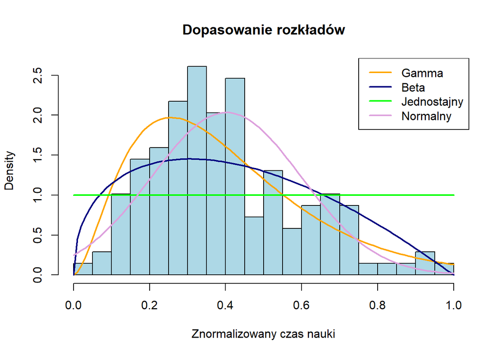

```r
# tutaj przy histogramach pomógł chat gpt, chciałam sprawdzić czy rzeczywiście histogram najlepiej przybliżony jest poprzez rozkład normalny
hist(normalized_value1, breaks = 28, prob = TRUE, main = "Dopasowanie rozkładów", xlab = "Znormalizowany czas nauki", col = "lightblue")
curve(dgamma(x, shape = fit_gamma$estimate["shape"], rate = fit_gamma$estimate["rate"]), add = TRUE, col = "orange", lwd = 2)
curve(dbeta(x, shape1 = fit_beta$estimate["shape1"], shape2 = fit_beta$estimate["shape2"]), add = TRUE, col = "navy", lwd = 2)
curve(dunif(x, min = 0, max = 1), add = TRUE, col = "green", lwd = 2)
curve(dnorm(x, mean = fit_norm$estimate["mean"], sd = fit_norm$estimate["sd"]), add = TRUE, col = "plum", lwd = 2)
legend("topright", legend = c("Gamma", "Beta", "Jednostajny", "Normalny"),
       col = c("orange", "navy", "green", "plum"), lwd = 2)
```

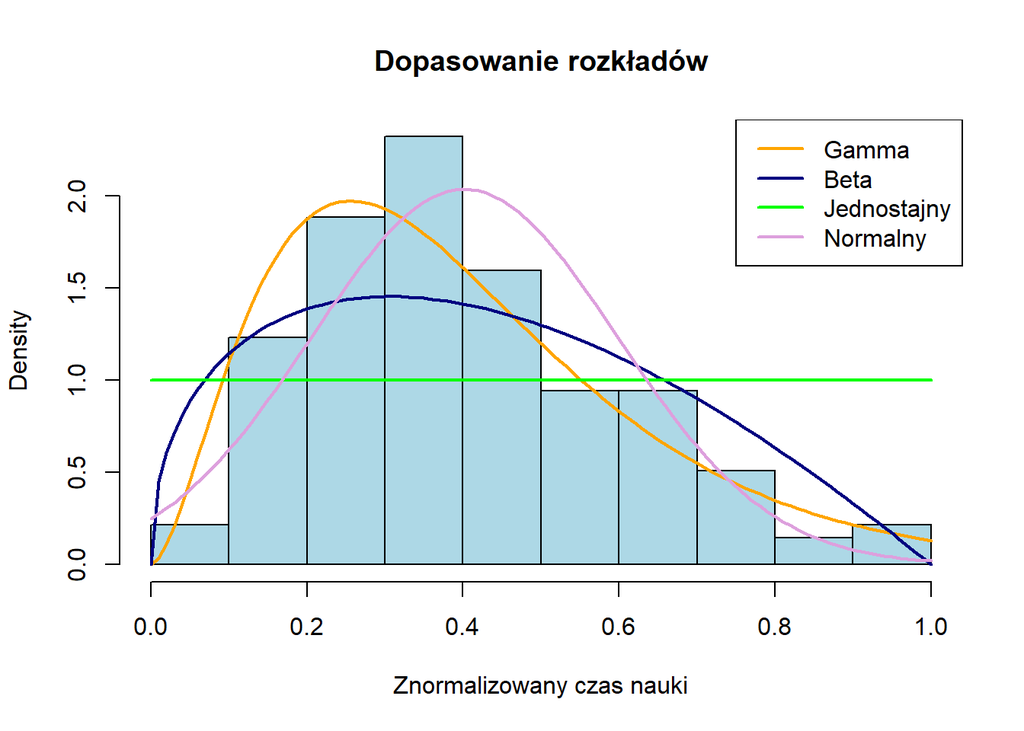

```r
# teraz mniej breaks

hist(normalized_value1, breaks = 14, prob = TRUE, main = "Dopasowanie rozkładów", xlab = "Znormalizowany czas nauki", col = "lightblue")
curve(dgamma(x, shape = fit_gamma$estimate["shape"], rate = fit_gamma$estimate["rate"]), add = TRUE, col = "orange", lwd = 2)
curve(dbeta(x, shape1 = fit_beta$estimate["shape1"], shape2 = fit_beta$estimate["shape2"]), add = TRUE, col = "navy", lwd = 2)
curve(dunif(x, min = 0, max = 1), add = TRUE, col = "green", lwd = 2)
curve(dnorm(x, mean = fit_norm$estimate["mean"], sd = fit_norm$estimate["sd"]), add = TRUE, col = "plum", lwd = 2)
legend("topright", legend = c("Gamma", "Beta", "Jednostajny", "Normalny"),
       col = c("orange", "navy", "green", "plum"), lwd = 2)
```

Na podstawie każdej ze statystyk, najlepszy rozkład dla czasu nauki studentów kierunku Psychologia to rozkład normalny.

# Wykres zależności średniej ocen od czasu nauki dla kierunku “Biologia”.

- Stwórz wykres punktowy, przedstawiający zależność średniej ocen od czasu nauki dla kierunku “Biologia”. Wykres powinien mieć podpisane osie, tytuł, zmienione kolory oraz legendę.
- Na podstawie wykresu określ, jaki rodzaj zależności występuje między zmiennymi. Oblicz korelację między średnią ocen a czasem nauki. Sprawdź założenia regresji liniowej, wyestymuj współczynniki prostej regresji i dodaj ją na wykres. Przeprowadź również diagnostykę modelu za pomocą odpowiednich wykresów.

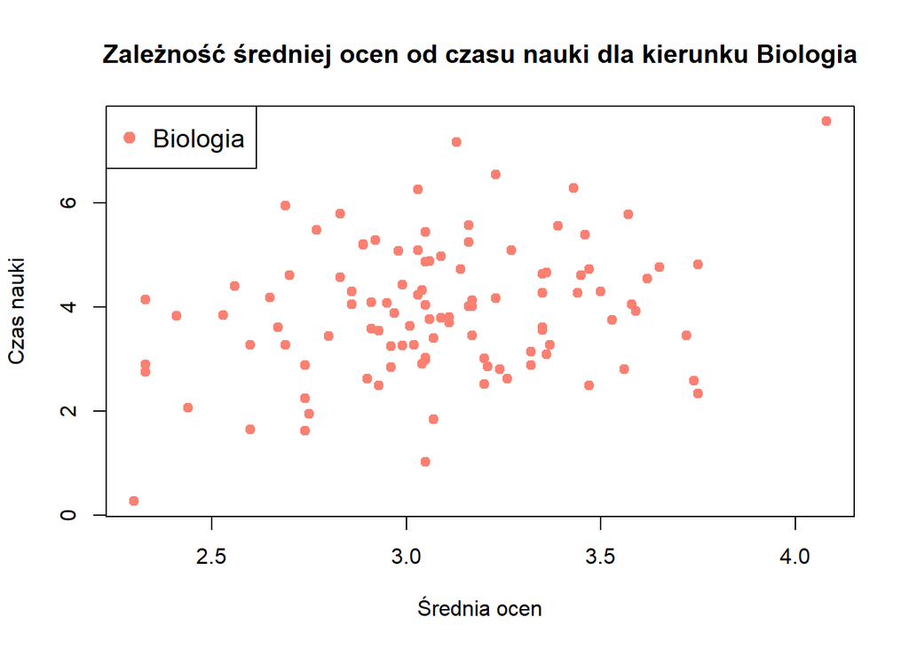

```r
kierunek_biologia <- dane[dane$Kierunek_studiów == "Biologia", ]
plot(x=kierunek_biologia$Średnia_ocen,y=kierunek_biologia$Czas_nauki, type="p",pch=19, col="salmon",main="Zależność średniej ocen od czasu nauki dla kierunku Biologia",xlab="Średnia ocen",ylab="Czas nauki")
legend("topleft",legend="Biologia",col="salmon",pch=19,cex=1.2)
```

```r
korelacja=cor(kierunek_biologia$Średnia_ocen,kierunek_biologia$Czas_nauki)
korelacja #obliczony współczynnik
```

```
## [1] 0.2669894
```

```r
#założenia regresji liniowej i diagnostyka modelu
model_liniowy_biologia <- lm(kierunek_biologia$Średnia_ocen~kierunek_biologia$Czas_nauki)
shapiro.test(residuals(model_liniowy_biologia))
```

```
##
##  Shapiro-Wilk normality test
##
## data:  residuals(model_liniowy_biologia)
## W = 0.99184, p-value = 0.7798
```

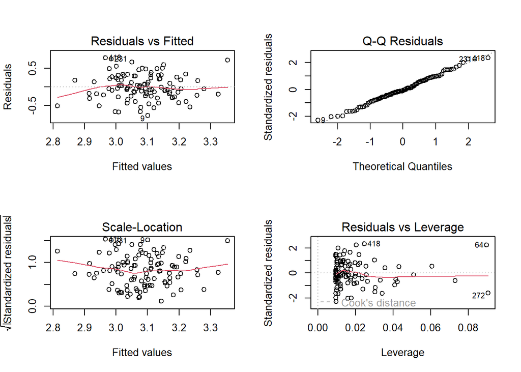

```r
# W = 0.99184: to wysoka wartość; reszty są bliskie normalnemu rozkładowi
# p-value = 0.7798: większa niż standardowy poziom istotności ; brak podstaw do odrzucenia
# czyli test Shapiro-Wilka wskazuje, że założenie o normalności reszt jest spełnione.


# diagnostyka modelu
par(mfrow = c(2, 2))  # Wykresy diagnostyczne w układzie 2x2
plot(model_liniowy_biologia) # cztery ważne wykresy
```

```r
#wyestymowane współczynniki
model_liniowy_biologia$coefficients
```

```
##                  (Intercept) kierunek_biologia$Czas_nauki
##                   2.79360439                   0.07406229
```

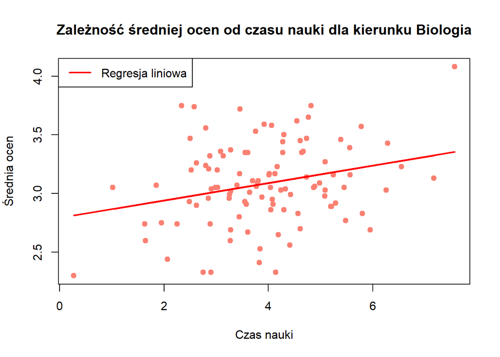

```r
# dodanie linii regresji
par(mfrow = c(1, 1))
plot(x=kierunek_biologia$Czas_nauki,y=kierunek_biologia$Średnia_ocen, type="p",pch=19, col="salmon",main="Zależność średniej ocen od czasu nauki dla kierunku Biologia",xlab="Czas nauki",ylab="Średnia ocen")

#dodanie wyestymowanych współczynników na wykres
a = model_liniowy_biologia$coefficients[2]  # Czas_nauki
b = model_liniowy_biologia$coefficients[1]  # Intercept
x = kierunek_biologia$Czas_nauki
y_regression = a * x + b

# rysowanie linii regresji
lines(x, y_regression, type = "l", col = "red", lwd = 2)
legend("topleft", legend = "Regresja liniowa", col = "red", lwd = 2)
```

Wniosek z wykresu: Ogólnie można powiedzieć, że im więcej godzin studenci poświęcają na naukę, tym wyższa jest ich średnia ocen.

Założenia regresji liniowej:

Postać modelu liniowego: mój wykres wskazuje lekką krzywiznę, co może sugerować niewielkie naruszenie liniowości.

Normalność reszt: punkty układają się prawie wzdłuż linii prostej, co oznacza, że normalność jest w dużej mierze zachowana.

Homoskedastyczność - wariancja błędów (zmiennych ϵ) jest stała: na wykresie rozrzut reszt jest w miarę równomierny, lecz nie stały.

Zmienne ϵ są niezależne i mają rozkład normalny o średniej 0: na wykresie większość punktów jest zgromadzona blisko punktu 0,0. Przeprowadzony test Shapiro-Wilka wskazuje, że założenie o normalności reszt jest spełnione.